# Steps for building models

# Steps for Design and Implement your model

- Diagram your model
- Translate diagram into a mathematical representation
- Choose programming language
- Define inputs (data type, units)
- Define output (data type, units)
- Define model structure
- Write model
- Document the model (meta data)
- Test model

# Building Models

Modularity! (Functions)

The basic building blocks of models

Functions can be written in all languages; in many languages (object-oriented) like C++, Python, functions are also objects

Functions are the “boxes” of the model - the transfer function that takes inputs and returns outputs

More complex models - made up of multiple functions; and nested functions (and main functions that call/user other functions and control the flow - the arrows between boxes)

# Modularity

[figure not shown]

For each box/function Decide on

- Inputs and parameters
- Outputs

Data types, units (time and space aggregation), names should be (use descriptive names)

**IMPORTANT**

Place each function in its own file (x.R), and put all functions for a given project in *R* subdirectory

# What’s in the box

Often more complicated than a simple single equation (regression results)

So we need to think through steps are - what is connected with what

Diagrams are a good place to start

# Modularity - Discrete Tasks

Hierarchical in level of details

Big chunks (coarse detail) -> progressively finer

Note ‘tasks’ that need to be repeated

All tasks should have inputs and outputs

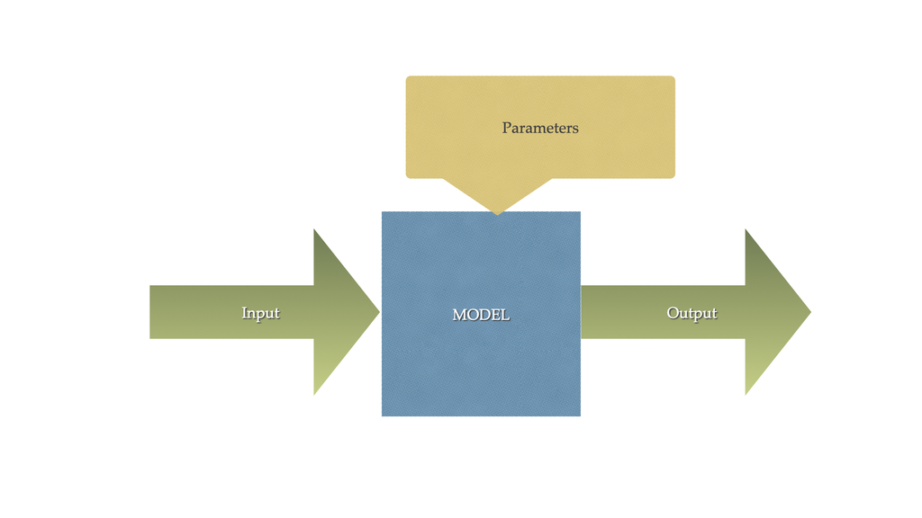

# Composing Diagrams

Pictorial representation your model and what needs to be included in the model to answer your questions (or achieve your modelling goal)

There are many software tools available for generating conceptual models, I like

# Model design flowcharts

Some model designers uses standard symbols for the different model components

Building Models

[figure not shown]

# • PhD of Norman Crawford under supervision of Ray K Linsley at Stanford University in 1962

Flow Charges

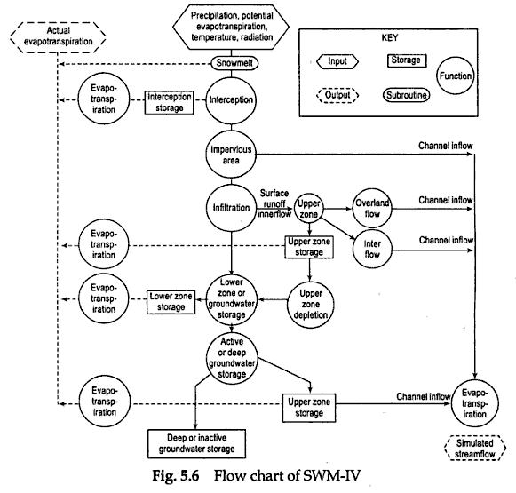

# SERI-Fire

- More complex model couple sub-models ( may be a loose coupling where users connects submodels)
- How do ecological and human factors interact to influence fire regimes

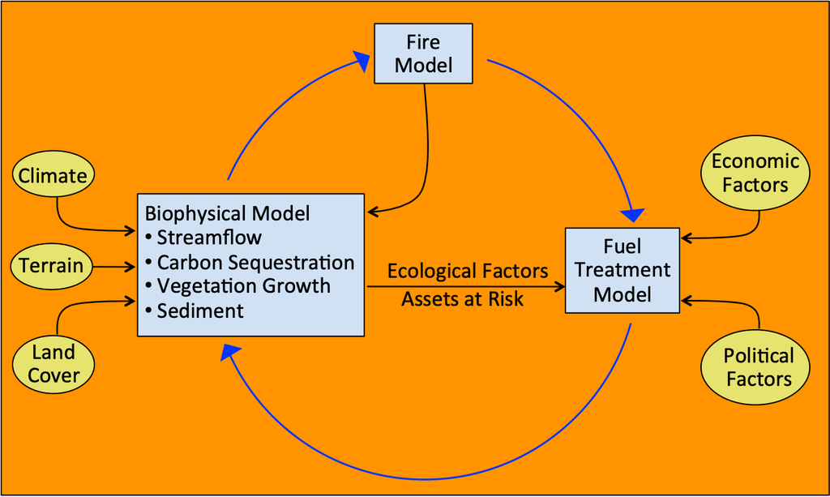

# Sharing Example R, Data and Rmarkdowns

You can clone this repository and then pull before class to get example code and data

Remember that git does not like having nested repositories - so keep working respoistories in separate directories

# Running Models with Data

- solarpv.R
- InformalSensitivity.Rmd
- InformalSensitivity2.Rmd

# Solar function example

**Design** - function that estimates solar pv power given inputs of radiation

**Model inputs**: solar radiation (daily direct and diffuse)

**Model outputs**: power generated each year and average power over time

**Parameters**: panel efficiency, system performance, units, type of array (uses diffuse or not), plot Y/N

Some of these options such as whether to plot determine outputs from the function

AND the type of array to determine whether it uses diffuse radiation, these parameters change how the function/model works

# Solar function example as code (InformalSensitivity.Rmd)

Model Code

```
## function (area, eff = 0.8, PR = 0.75, solar, clr = "blue", eunits = "J",
##     etype = "both", g = TRUE, ethresh = 10000)
## {
##     if (etype == "diffuse") {
##         solar$total = solar$Kdown_diffuse
##     }
##     else {
##         if (etype == "direct") {
##             solar$total = solar$Kdown_direct
##         }
##         else {
##             solar$total = solar$Kdown_direct + solar$Kdown_diffuse
##         }
##     }
##     adjusteff = function(x, ethresh, eff) {
##         result = ifelse((x > ethresh), eff * x, x * eff * (max(0,
##             x/ethresh)))
##         return(result)
##     }
##     solar = solar %>% mutate(Kadj = adjusteff(total, ethresh = ethresh,
##         eff = eff))
##     annualsolar = solar %>% group_by(year) %>% dplyr::summarize(Kadj = sum(Kadj))
##     annualsolar$elect = area * PR * annualsolar$Kadj
##     ylbs = "kJ/yr"
##     if (eunits == "W") {
##         annualsolar$elect = annualsolar$elect * 0.278
##         ylbs = "Wh/yr"
##     }
##     if (g)
##         barplot(annualsolar$elect, names = annualsolar$year,
##             col = clr, ylab = ylbs, xlab = "Year")
##     return(list(annual = annualsolar[, c("year", "elect")], mean = mean(annualsolar$elect)))
## }
```

# Some Data

```r
# read in R formatted data
load("../Data/sierraczosolar.rda")

# already in the format required for the model
head(sierraczosolar)
```

```
##   day month year Kdown_direct Kdown_diffuse
## 1   1    10 1944     9160.645      6723.084
## 2   2    10 1944    13012.744      5961.513
## 3   3    10 1944    14080.951      5658.144
## 4   4    10 1944    11818.719      6257.914
## 5   5    10 1944    13563.701      5809.291
## 6   6    10 1944    11653.709      5652.240
```